# EDA - Wk3 - Hierarchical Clustering

MCCurcio

1/3/2021

# 1 EDA - Wk3

## 1.1 Hierarchical Clustering (part 1)

[HCA](https://en.wikipedia.org/wiki/Hierarchical_clustering) Good for viz of multi or high-dim data.

Good For:

- defining closeness
- defining groups
- viz of groups
- interpretation of groups

General Types

- Agglomerative: This is a “bottom-up” approach: each observation starts in its own cluster, and pairs of clusters are merged as one moves up the hierarchy.
  - finds closest things
  - groups obj.
  - req. distance measurement of some sort
    - euclidean dist.
    - correlation similarity
    - binary-Manhattan dist.
    - cos($\theta$)
  - merges items into groups
  - produces: tree structure, *dendrogram*
- Divisive: **LATER** This is a “top-down” approach: all observations start in one cluster, and splits are performed recursively as one moves down the hierarchy.

## 1.2 Hierarchical Clustering (part 2)

### 1.2.1 Example 1

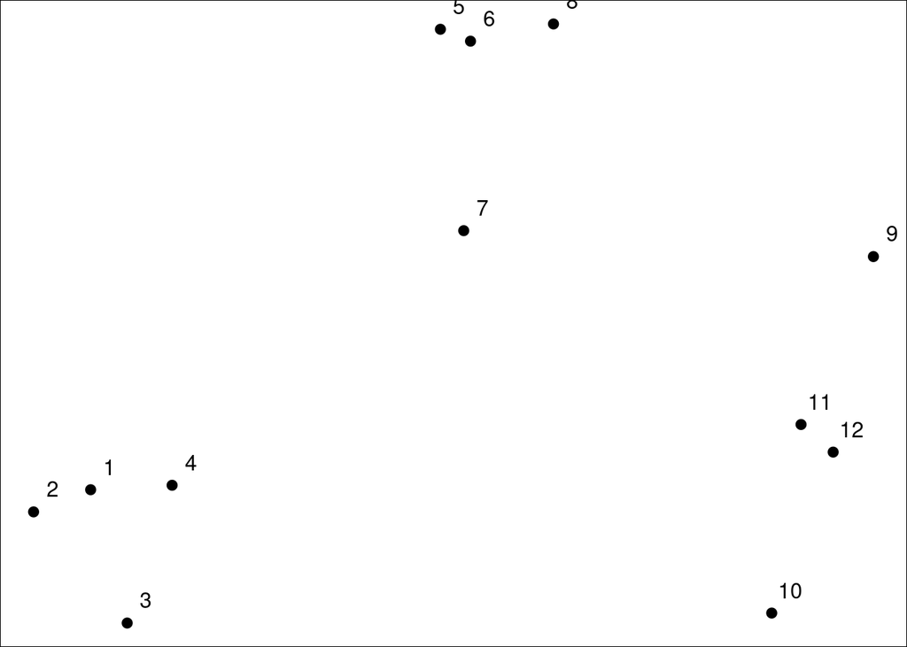

```r
set.seed(1000)
par(mar=c(0,0,0,0))
x <- rnorm(12, mean=rep(1:3, each=4), sd=0.2)
y <- rnorm(12, mean = rep(c(1,2,1), each=4), sd=0.2)
plot(x, y, pch=19)
text(x + 0.05, y + 0.05, labels=as.character(1:12))
```

### 1.2.2 Step 1: dist measures

```r
dataFrame <- data.frame(x=x, y=y)
dist(dataFrame) # calcs pair wise dist
```

```
##             1          2          3          4          5          6          7
## 2  0.15955009
## 3  0.30732105 0.34822989
## 4  0.21725157 0.37360777 0.32411420
## 5  1.37180871 1.51267307 1.54328072 1.22677336
## 6  1.40927405 1.55378217 1.56687997 1.25493271 0.08433063
## 7  1.14403536 1.30052313 1.24091532 0.95578890 0.44469545 0.41469758
## 8  1.59924856 1.74832347 1.73365201 1.43168299 0.30148484 0.22423051 0.51130916
## 9  2.14684734 2.30604588 2.14345381 1.93416664 1.25611538 1.17217542 1.09294256
## 10 1.83446279 1.97895231 1.71728962 1.62175056 1.55189633 1.48574530 1.17147016
## 11 1.89803245 2.05358953 1.84701632 1.68089394 1.29227266 1.21571028 0.99361710
## 12 1.97996653 2.13427858 1.91764617 1.76271628 1.39631059 1.31939177 1.09691300
##             8          9         10         11
## 2
## 3
## 4
## 5
## 6
## 7
## 8
## 9  0.99256693
## 10 1.41318371 0.82516099
## 11 1.09636583 0.41469975 0.41959243
## 12 1.19648056 0.44073501 0.38813928 0.10471677
```

```r
# Closest points are 5 & 6, dist=0.08433063
# Next set of close points is 11 & 12 (dist=0.10471677)...
```

### 1.2.3 Plot Dendrogram

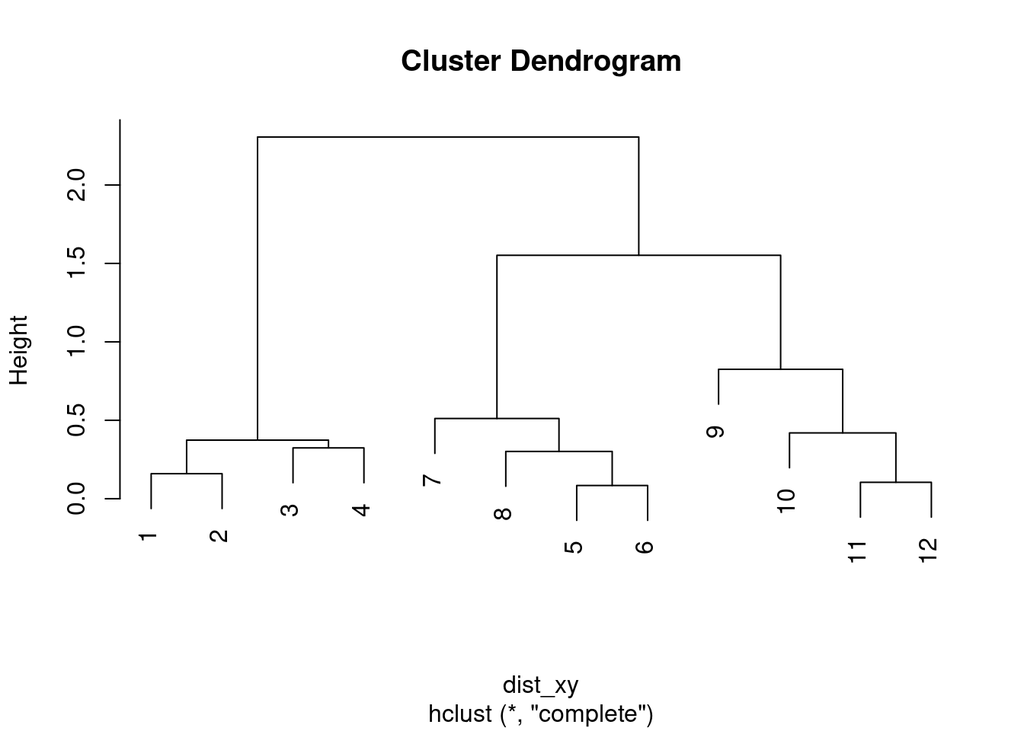

```r
dist_xy <- dist(dataFrame)
hClustering <- hclust(dist_xy)
plot(hClustering)
```

## 1.3 Hierarchical Clustering (part 3)

```r
myplclust <- function(hclust, lab=hclust$labels, lab.col=rep(1, length(hclust$labels)), hang=0.1, ...){
      # This is a mod of the plclust hclust objects *in color*!
      # From Eva KF Chan 2009
      # Arguments:
      # hclust=hclustobject,
      # lab=a character vector of labels of the leaves of the tree,
      # lab.col=color of the labels,
      # NA=default device foreground color,
      # hang=as in hclust & plculst,
      # Side effect=display of the hier' cluster with colored labels.
      y <- rep(hclust$height, 2)
      x <- as.numeric(hclust$merge)
      y <- y[which(x<0)]
      x <- x[which(x<0)]
      x <- abs(x)
      y <- y[order(x)]
      x <- x[order(x)]
      plot(hclust, labels=FALSE, hang=hang, ...)
      text(x=x,
           y=y[hclust$order] - (max(hclust$height) * hang),
           labels= lab[hclust$order],
           col=lab.col[hclust$order],
           srt=90,
           adj=c(1,0.5),
           xpd=NA, ...)
}
```

### 1.3.1 Dendrogram

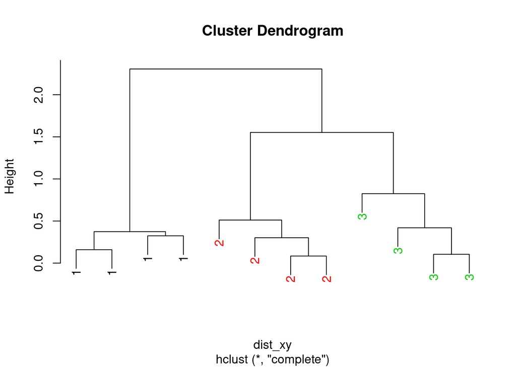

```r
myplclust(hClustering,
          lab = rep(1:3, each=4),
          lab.col = rep(1:3, each=4))
```

See Also: [R-Graph Gallery](https://www.r-graph-gallery.com/)  
See: [Dendrograms](https://www.r-graph-gallery.com/dendrogram.html)

### 1.3.2 How to Merge pts together

Q. What does it mean to be close? [TowardsDataScience.com](https://towardsdatascience.com/introduction-hierarchical-clustering-d3066c6b560e)

- [Average Linkage](https://support.minitab.com/en-us/minitab/18/help-and-how-to/modeling-statistics/multivariate/how-to/cluster-observations/methods-and-formulas/linkage-methods/)
  - Like the average of their X-coordinates and the average of their Y-coordinates.
  - Similar to “Centroid or Center of Mass”
- Complete-Linkage
  - “Complete-linkage (farthest neighbor) is where distance is measured between the farthest pair of observations in two clusters.”

### 1.3.3 Heatmaps()

- Good for tabular data - runs/uses Hier` clustering on the X then the Y vars.

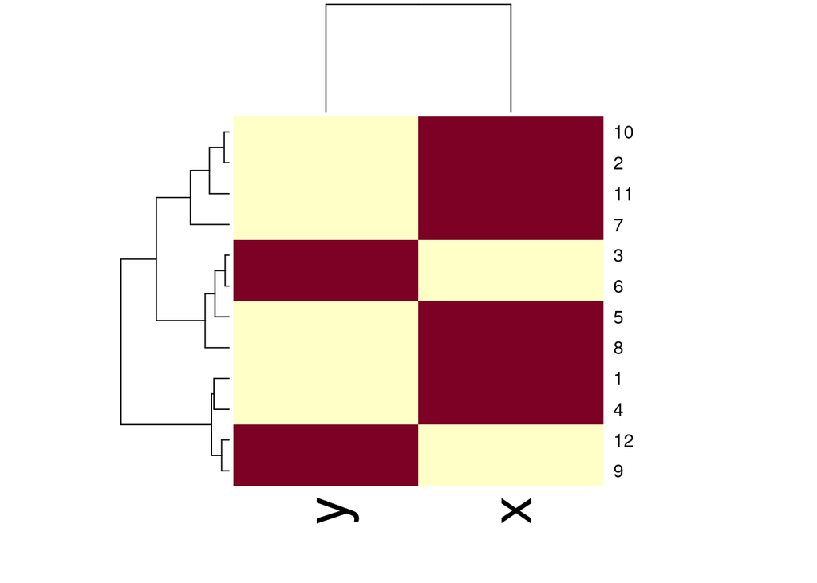

```r
dataFrame = data.frame(x=x, y=y)
set.seed(1000)
dataMatrix <- as.matrix(dataFrame)[sample(1:12),]
heatmap(dataMatrix)
```

- Provides an idea of relationships between var/obs.
- Can be unstable
- Sensitive to scaling

## 1.4 K-means Clustering (Part 1)

See: [K-Means 1](https://www.r-bloggers.com/2020/05/practical-guide-to-k-means-clustering/)

See: [K-Means-Wikipedia](https://en.wikipedia.org/wiki/K-means_clustering)

### 1.4.1 Wine Data - kmeans()

```r
library(rattle.data)
data(wine, package="rattle.data")
wine_subset <- scale(wine[ , c(2:4)])
wine_cluster <- kmeans(wine_subset,
                       centers = 3,
                       iter.max = 10,
                       nstart = 25)

wine_cluster
```

```
## K-means clustering with 3 clusters of sizes 48, 70, 60
##
## Cluster means:
##      Alcohol      Malic        Ash
## 1  0.1470536  1.3907328  0.2534220
## 2 -0.8649501 -0.5660390 -0.6371656
## 3  0.8914655 -0.4522073  0.5406223
##
## Clustering vector:
##   [1] 3 2 3 3 3 3 3 3 3 3 3 3 3 3 3 3 3 3 3 1 3 1 3 3 3 3 3 2 3 3 3 3 3 3 3 3 3
##  [38] 3 2 1 3 1 3 1 2 1 1 3 3 3 2 3 3 3 3 3 3 3 3 2 2 2 2 2 2 2 2 2 3 2 2 3 3 3
##  [75] 2 2 2 2 2 1 2 2 2 1 2 2 2 2 2 2 2 2 2 2 2 2 2 2 2 2 2 2 2 2 2 2 2 2 2 2 2
## [112] 2 1 2 2 2 2 2 1 2 2 3 1 1 1 2 2 2 2 1 2 1 2 1 2 2 1 1 1 1 1 3 1 1 1 1 1 1
## [149] 1 1 1 1 3 1 2 1 1 1 3 3 1 1 1 1 3 1 1 1 3 1 2 2 3 1 1 1 3 1
##
## Within cluster sum of squares by cluster:
## [1]  73.71460 111.63512  67.98619
##  (between_SS / total_SS =  52.3 %)
##
## Available components:
##
## [1] "cluster"      "centers"      "totss"        "withinss"     "tot.withinss"
## [6] "betweenss"    "size"         "iter"         "ifault"
```

## 1.5 K-Means Clustering (part 2)

### 1.5.1 Example 2 - kmeans()

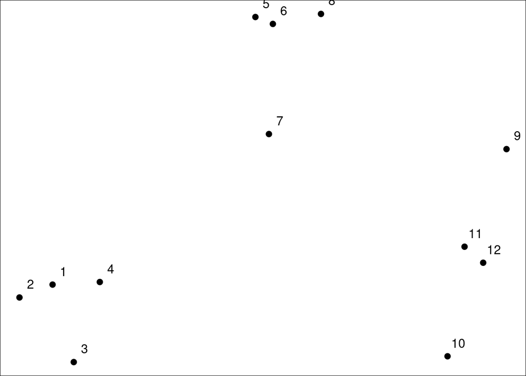

```r
set.seed(1000)
par(mar=c(0,0,0,0))
x <- rnorm(12, mean=rep(1:3, each=4), sd=0.2)
y <- rnorm(12, mean = rep(c(1,2,1), each=4), sd=0.2)
plot(x, y, pch=19)
text(x + 0.05, y + 0.05, labels=as.character(1:12))
```

```r
dataFrame <- data.frame(x,y)
kmeans_obj <- kmeans(dataFrame, centers = 3)
names(kmeans_obj)
```

```
## [1] "cluster"      "centers"      "totss"        "withinss"     "tot.withinss"
## [6] "betweenss"    "size"         "iter"         "ifault"
```

```r
kmeans_obj$cluster
```

```
##  [1] 2 2 2 2 1 1 1 1 3 3 3 3
```

### 1.5.2 Heatmaps & Clusters

The left-hand side is original while rt-hand side is ordered by rows.

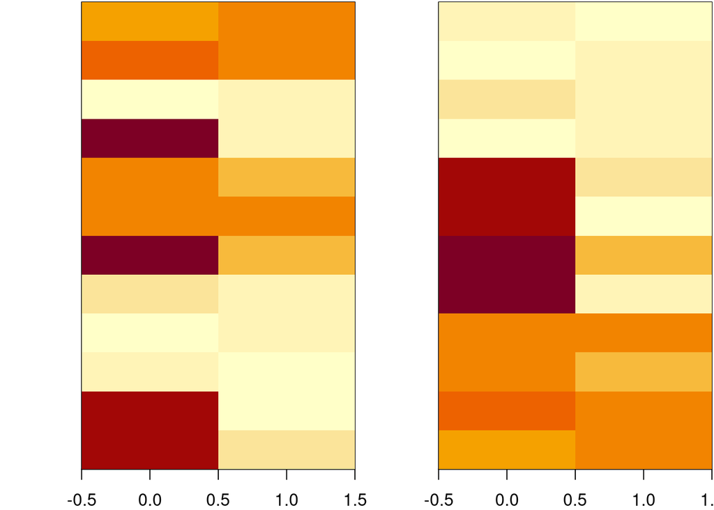

```r
set.seed(2000)
dataMatrix <- as.matrix(dataFrame)[sample(1:12),]
kmeans_obj2 <- kmeans(dataMatrix, centers = 3)
par(mfrow = c(1,2), mar = c(2,4,0.1,0.1))
image(t(dataMatrix)[, nrow(dataMatrix):1], yaxt = "n")
image(t(dataMatrix)[, order(kmeans_obj2$cluster)], yaxt = "n")
```

**NOTE**: It might be helpful to remember that [image](https://www.r-bloggers.com/2016/10/creating-an-image-of-a-matrix-in-r-using-image/) is a *BASE* R fucntion.

See: [Elements of Statistical Learning](https://web.stanford.edu/~hastie/ElemStatLearn/)

## 1.6 Dimension Reduction (part 1)

### 1.6.1 Principal Component Analysis & SVD

See: [PCA @ machinelearningplus.com](https://www.machinelearningplus.com/machine-learning/principal-components-analysis-pca-better-explained/)

See: [Dave Tang](https://davetang.org/file/Singular_Value_Decomposition_Tutorial.pdf)

### 1.6.2 EXAMPLE 1: Random Data Shows NO PATTERN

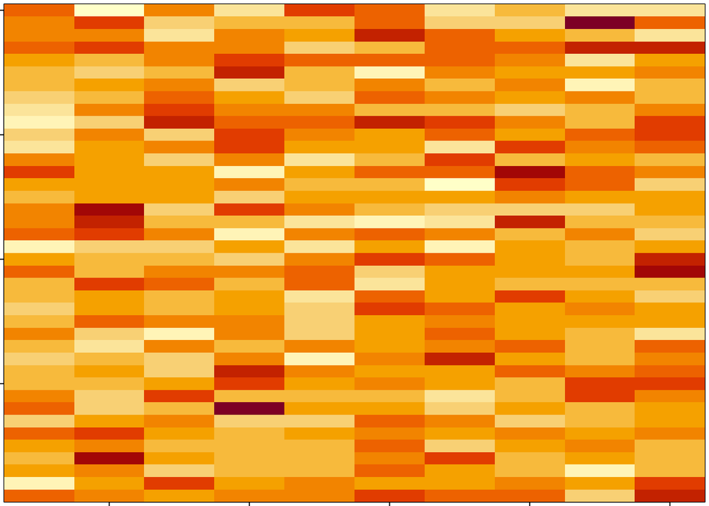

```r
set.seed(3000)
par(mar = rep(0.2, 4))
dataMatrix <- matrix(rnorm(400), nrow = 40)
image(1:10, 1:40, t(dataMatrix)[, nrow(dataMatrix):1])
```

One could do a Hier` cluster analysis of data

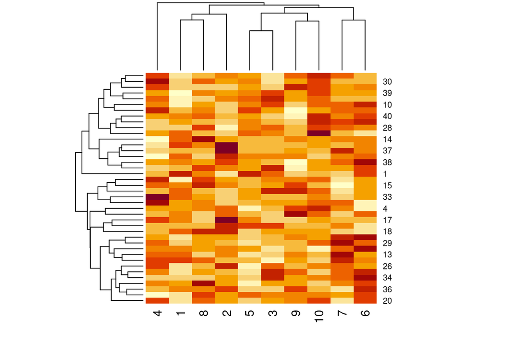

```r
par(mar = rep(0.2, 4))
heatmap(dataMatrix)
```

### 1.6.3 Ordered data

```r
set.seed(4000)
for (i in 1:40){
  # Use coin flips
  coinFlip <- rbinom(1, size=1, prob=0.5)
  if (coinFlip) {
    dataMatrix[i, ] <- dataMatrix[i, ] + rep(c(0,3), each=5)
  }
}
```

### 1.6.4 Plotting Heatmap of dataMatrix

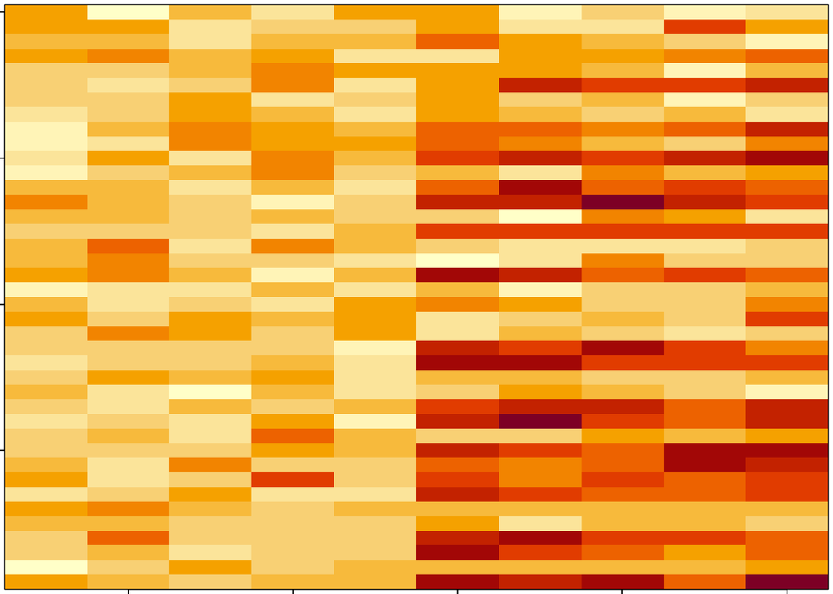

```r
par(mar = rep(0.2, 4))
image(1:10, 1:40, t(dataMatrix)[, nrow(dataMatrix):1])
```

### 1.6.5 Hier` Clustering analysis

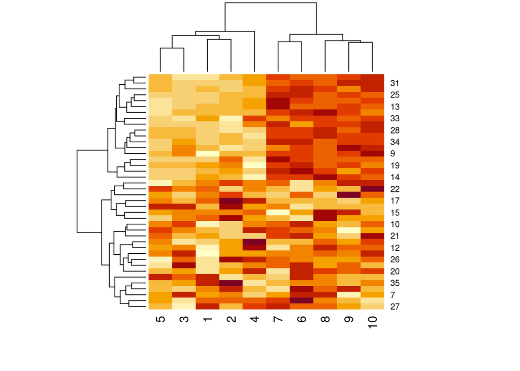

```r
par(mar = rep(0.2, 4))
heatmap(dataMatrix)
```

### 1.6.6 Patterns within Rows & Cols

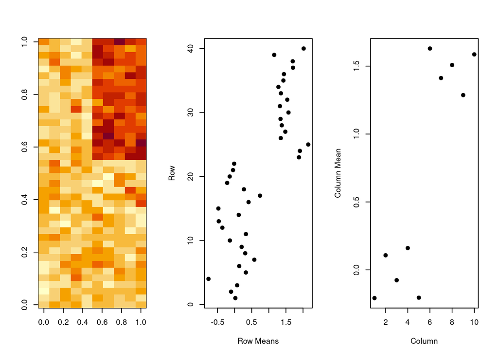

```r
hh <- hclust(dist(dataMatrix))
dataMatrix_Ordered <- dataMatrix[hh$order,]
par(mfrow = c(1,3))
#a
image(t(dataMatrix_Ordered)[, nrow(dataMatrix_Ordered):1])
#b
plot(rowMeans(dataMatrix_Ordered),
     40:1,
     xlab = "Row Means",
     ylab = "Row",
     pch = 19)
#c
plot(colMeans(dataMatrix_Ordered),
     xlab = "Column",
     ylab = "Column Mean",
     pch = 19)
```

## 1.7 Dimension Reduction (part 2)

### 1.7.1 PCA Example

- Components of the SVD; $u$ & $v$

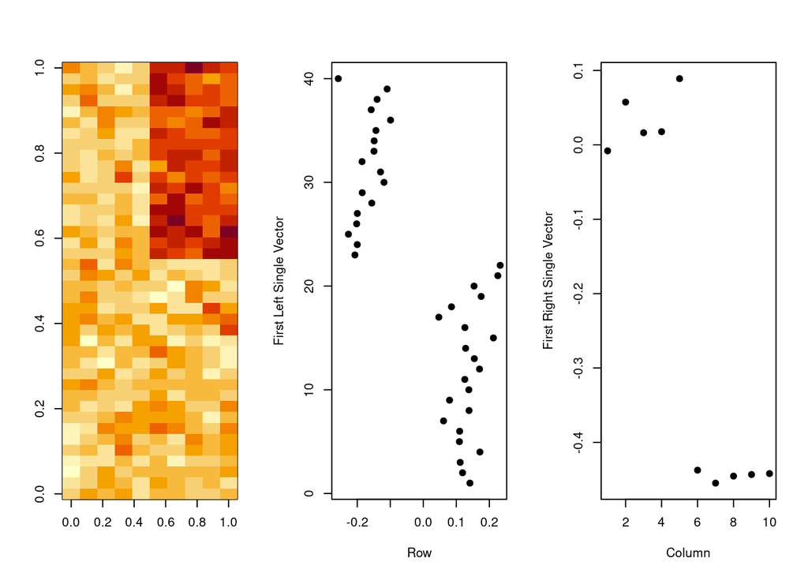

```r
svd1 <- svd(scale(dataMatrix_Ordered))
par(mfrow = c(1,3))
#a
image(t(dataMatrix_Ordered)[, nrow(dataMatrix_Ordered):1])
#b
plot(svd1$u[, 1],
     40:1,
     xlab = "Row",
     ylab = "First Left Single Vector",
     pch = 19)
#c
plot(svd1$v[, 1],
     xlab = "Column",
     ylab = "First Right Single Vector",
     pch = 19)
```

### 1.7.2 Variance Explained #1

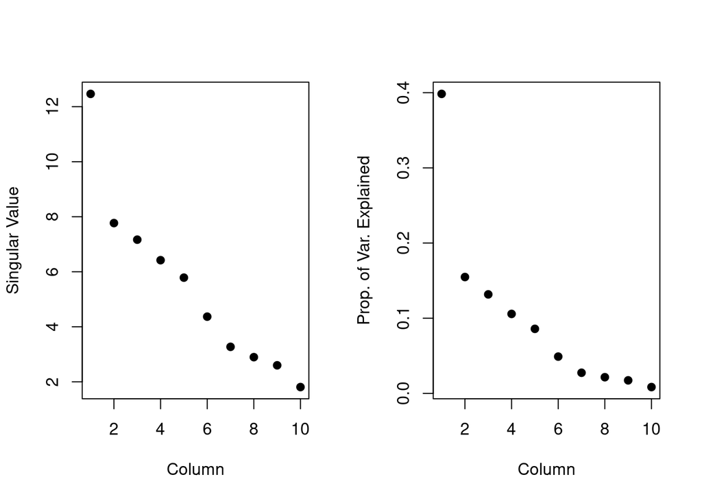

```r
par(mfrow = c(1,2))
#a
plot(svd1$d,
     xlab = "Column",
     ylab = "Singular Value",
     pch = 19)
#b
plot(svd1$d^2/sum(svd1$d^2),
     xlab = "Column",
     ylab = "Prop. of Var. Explained",
     pch = 19)
```

### 1.7.3 Relationship of SVD to PCA

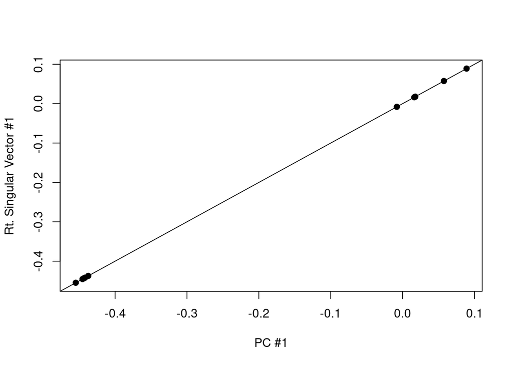

```r
svd1 <- svd(scale(dataMatrix_Ordered))
pca1 <- prcomp(dataMatrix_Ordered, scale. = TRUE)
plot(pca1$rotation[, 1],
     svd1$v[,1],
     xlab = "PC #1",
     ylab = "Rt. Singular Vector #1",
     pch = 19)
abline(c(0,1))
```

### 1.7.4 A Closer Look at SVD Variance Explained

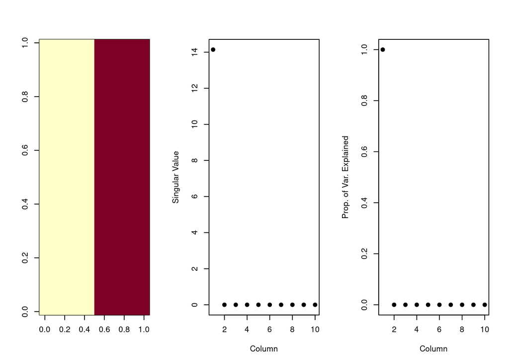

```r
constantMatrix <- dataMatrix_Ordered*0
for (i in 1:dim(dataMatrix_Ordered)[1]){
    constantMatrix[i,] <- rep(c(0,1), each=5)
}
svd1 <- svd(constantMatrix)
par(mfrow=c(1,3))
#a
image(t(constantMatrix)[, nrow(constantMatrix):1])
#b
plot(svd1$d,
     xlab = "Column",
     ylab = "Singular Value",
     pch = 19)
#c
plot(svd1$d^2/sum(svd1$d^2),
     xlab = "Column",
     ylab = "Prop. of Var. Explained",
     pch = 19)
```

### 1.7.5 Adding a Second Pattern to Dataset

```r
set.seed(9999)
for (i in 1:40) {
  # coin flip
  coinFlip1 <- rbinom(1, size = 1, prob = 0.5) # 1D
  coinFlip2 <- rbinom(1, size = 1, prob = 0.5) # 2D
   if (coinFlip1) {
     dataMatrix[i, ] <- dataMatrix[i, ] + rep(c(0,5), each=5)
   }
   if (coinFlip2) {
    dataMatrix[i, ] <- dataMatrix[i, ] + rep(c(0,5), each=5)
   }
}
hh <- hclust(dist(dataMatrix))
dataMatrix_Ordered <- dataMatrix[hh$order, ]
```

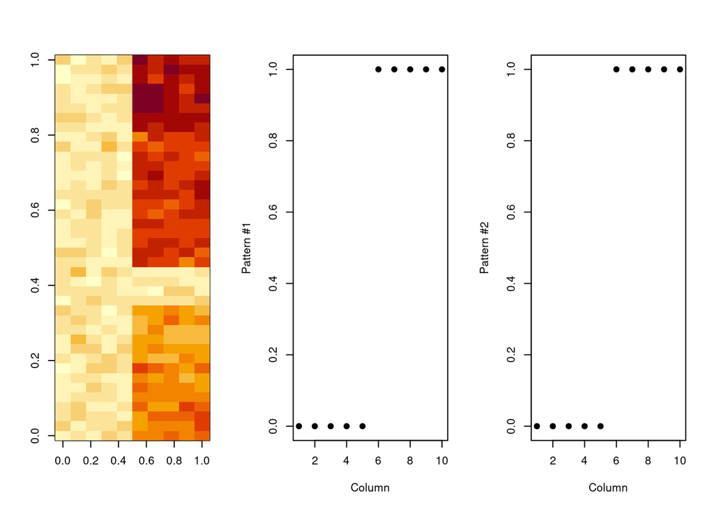

```r
svd2 <- svd(scale(dataMatrix_Ordered))
par(mfrow=c(1,3))
#a
image(t(dataMatrix_Ordered)[, nrow(dataMatrix_Ordered):1])
#b
plot(rep(c(0,1), each=5),
     xlab = "Column",
     ylab = "Pattern #1",
     pch = 19)
#c
plot(rep(c(0,1), each=5),
     xlab = "Column",
     ylab = "Pattern #2",
     pch = 19)
```

### 1.7.6 $v$ & Patterns of Variance in Rows

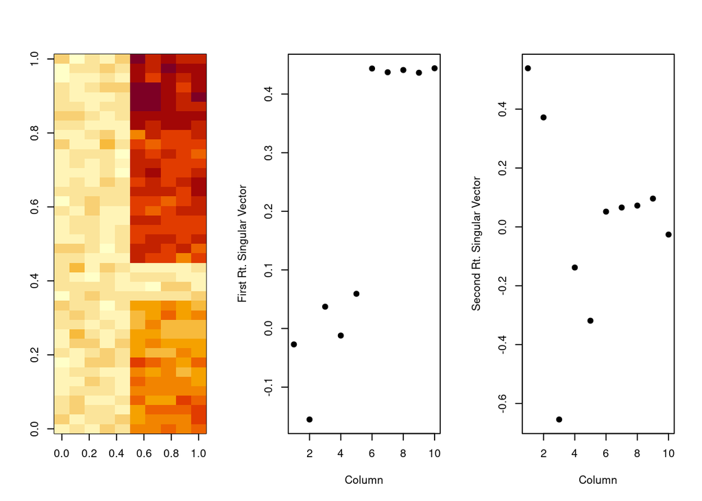

```r
svd2 <- svd(scale(dataMatrix_Ordered))
par(mfrow=c(1,3))
#a
image(t(dataMatrix_Ordered)[, nrow(dataMatrix_Ordered):1])
#b
plot(svd2$v[,1],
     xlab = "Column",
     ylab = "First Rt. Singular Vector",
     pch = 19)
#c
plot(svd2$v[,2],
     xlab = "Column",
     ylab = "Second Rt. Singular Vector",
     pch = 19)
```

### 1.7.7 Variance Explained #2

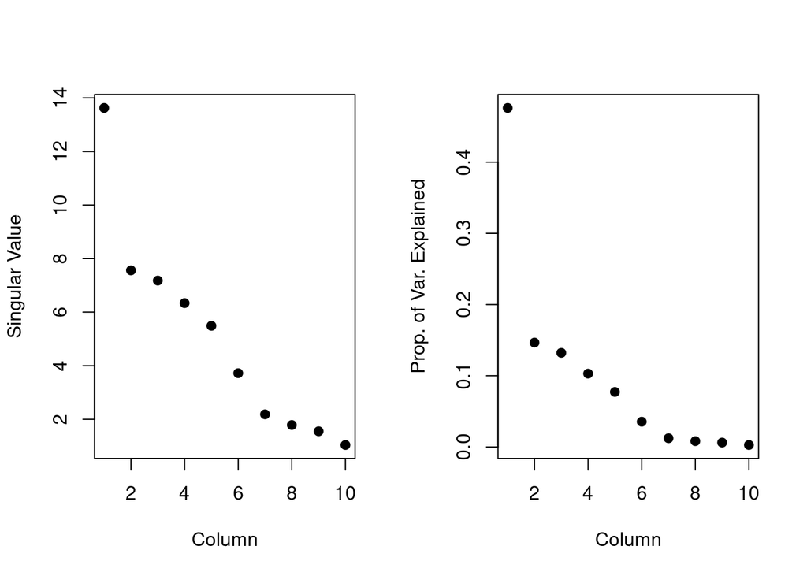

```r
svd1 <- svd(scale(dataMatrix_Ordered))
par(mfrow = c(1,2))
#a
plot(svd1$d,
     xlab = "Column",
     ylab = "Singular Value",
     pch = 19)
#b
plot(svd1$d^2/sum(svd1$d^2),
     xlab = "Column",
     ylab = "Prop. of Var. Explained",
     pch = 19)
```

## 1.8 Dimension Reduction (part 3)

### 1.8.2 Libraries For Imputation:

- `imputeMissings` Impute Missing Values in a Predictive Context
- `ClustImpute` K-means clustering with build-in missing data imputation, See [R-Bloggers.com](https://www.r-bloggers.com/2019/06/intoducing-clustimpute-a-new-approach-for-k-means-clustering-with-build-in-missing-data-imputation/)
- `yaImpute` Nearest Neighbor Observation Imputation and Evaluation Tools
- `imputeR` A General Multivariate Imputation Framework
- `eimpute` Efficiently Impute Large Scale Incomplete Matrix

### 1.8.3 Imputing Values w/ `imputeMissings`

Compute the values on a training dataset and impute them on new data. This is very convenient in predictive contexts.

### 1.8.4 Example #1 - `imputeMissings` w/ Median/Mode method

```r
library(imputeMissings)

# Define training data
train <- data.frame(v_int=as.integer(c(3,3,2,5,1,2,4,6)),
                    v_num=as.numeric(c(4.1,NA,12.2,11,3.4,1.6,3.3,5.5)),
                    v_fact=as.factor(c('one','two',NA,'two','two','one','two','two')),
                    stringsAsFactors = FALSE)
train
```

```
##   v_int v_num v_fact
## 1     3   4.1    one
## 2     3    NA    two
## 3     2  12.2   <NA>
## 4     5  11.0    two
## 5     1   3.4    two
## 6     2   1.6    one
## 7     4   3.3    two
## 8     6   5.5    two
```

### 1.8.5 Compute values on **train** dataset - *Median/mode* method

```r
values <- compute(train)
values
```

```
## $v_int
## [1] 3
##
## $v_num
## [1] 4.1
##
## $v_fact
## [1] "two"
```

### 1.8.6 Example #2 - `imputeMissings` Using **randomForest** method

```r
# Define newdata
newdata <- data.frame(v_int=as.integer(c(1,1,2,NA)),
                      v_num=as.numeric(c(1.1,NA,2.2,NA)),
                      v_fact=as.factor(c('one','one','one',NA)),
                      stringsAsFactors = FALSE)
newdata
```

```
##   v_int v_num v_fact
## 1     1   1.1    one
## 2     1    NA    one
## 3     2   2.2    one
## 4    NA    NA   <NA>
```

### 1.8.7 Locate the NA’s

```r
is.na(newdata)
```

```
##      v_int v_num v_fact
## [1,] FALSE FALSE  FALSE
## [2,] FALSE  TRUE  FALSE
## [3,] FALSE FALSE  FALSE
## [4,]  TRUE  TRUE   TRUE
```

### 1.8.8 How many missings per variable?

```r
colSums(is.na(newdata))
```

```
##  v_int  v_num v_fact
##      1      2      1
```

### 1.8.9 Impute on newdata using randomForest values

```r
values2 <- compute(train, method = "randomForest")
impute(newdata, object = values2) # using randomForest values
```

```
##      v_int    v_num v_fact
## 1 1.000000 1.100000    one
## 2 1.000000 3.906133    one
## 3 2.000000 2.200000    one
## 4 2.472483 3.906133    one
```

### 1.8.10 Impute on newdata Using Median/Mode values

```r
impute(newdata, object = values) # using median/mode values
```

```
##   v_int v_num v_fact
## 1     1   1.1    one
## 2     1   4.1    one
## 3     2   2.2    one
## 4     3   4.1    two
```

### 1.8.11 One can also impute directly in newdata without the compute step

```r
impute(newdata)
```

```
##   v_int v_num v_fact
## 1     1  1.10    one
## 2     1  1.65    one
## 3     2  2.20    one
## 4     1  1.65    one
```

### 1.8.12 Flag parameter

```r
impute(newdata, flag = TRUE)
```

```
##   v_int v_num v_fact v_int_flag v_num_flag v_fact_flag
## 1     1  1.10    one          0          0           0
## 2     1  1.65    one          0          1           0
## 3     2  2.20    one          0          0           0
## 4     1  1.65    one          1          1           1
```

## 1.9 Working with Color in R Plots (part 1)

Examples: heat.colors(), topo.colors()

## 1.10 Working with Color in R Plots (part 2)

- In `grDevices` package for R;
  - `colorRamp` - Input is 0,1
  - `colorRampPalette` - Input colors & returns vector of colors
  - `colors()` - Returns color names

```r
library(grDevices)

pal <- colorRamp(c("red", "green"))( (0:4)/4 )
# (x) , x in [0,1]
```

```r
pal
```

```
##        [,1]   [,2] [,3]
## [1,] 255.00   0.00    0
## [2,] 191.25  63.75    0
## [3,] 127.50 127.50    0
## [4,]  63.75 191.25    0
## [5,]   0.00 255.00    0
```

### 1.10.1 ColorRamp

```r
library(RColorBrewer)

pal <- colorRamp(c("red", "green"))

pal(seq(0,1, length.out = 10))
```

```
##            [,1]      [,2] [,3]
##  [1,] 255.00000   0.00000    0
##  [2,] 226.66667  28.33333    0
##  [3,] 198.33333  56.66667    0
##  [4,] 170.00000  85.00000    0
##  [5,] 141.66667 113.33333    0
##  [6,] 113.33333 141.66667    0
##  [7,]  85.00000 170.00000    0
##  [8,]  56.66667 198.33333    0
##  [9,]  28.33333 226.66667    0
## [10,]   0.00000 255.00000    0
```

### 1.10.2 ColorRampPalette

Returns Hex colors

```r
pal <- colorRampPalette(c("red", "yellow"))

pal(4) # number indicates output n-length
```

```
## [1] "#FF0000" "#FF5500" "#FFAA00" "#FFFF00"
```

## 1.11 Working with Color in R Plots (part 3)

**RColorBrewer** package

In general, there are **3 palettes**:

1. Sequential
   - Sequential data classes are logically arranged from high to low
2. [Diverging](http://personal.psu.edu/cab38/ColorSch/SchHTMLs/CBColorDiv.html)
   - Diverging schemes allow the emphasis of a quantitative data display to be progressions outward from a critical midpoint of the data range.
3. [Qualitiative](http://personal.psu.edu/cab38/ColorSch/Schemes.html)
   - Used for categorical data

**Excellent Examples Palettes**

- [Color Brewer Webpage](https://colorbrewer2.org/#type=qualitative&scheme=Accent&n=3)

### 1.11.1 More Examples

```r
library(RColorBrewer)

cols <- brewer.pal(3, "BuGn")
cols
```

```
## [1] "#E5F5F9" "#99D8C9" "#2CA25F"
```

```r
pal <- colorRampPalette(cols)
# image(_image_file_, col = pal(20))
```

### 1.11.2 smoothScatter

Using color with Scatter plots

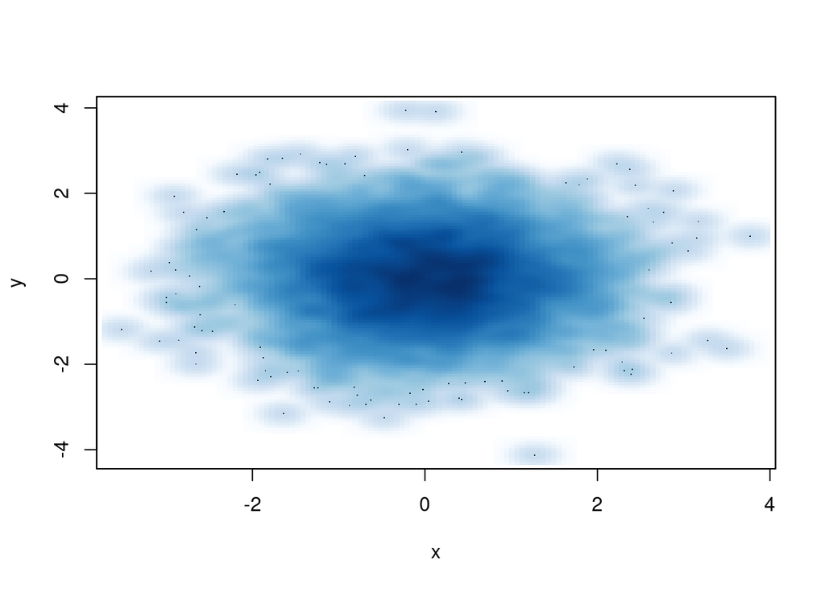

```r
set.seed(1500)
x <- rnorm(5000)
y <- rnorm(5000)
smoothScatter(x, y)
```

## 1.12 Working with Color in R Plots (part 4)

Other useful color plotting funcs:

1. `rgb`
2. color transparency - added via **alpha** to `rgb`
3. `colorspace` package used for different color controls

## 1.13 Practical R Exercises with swirl

- Practice Programming Assignment: swirl Lesson 1: Hierarchical Clustering
- Practice Programming Assignment: swirl Lesson 2: K Means Clustering
- Practice Programming Assignment: swirl Lesson 3: Dimension Reduction
- Practice Programming Assignment: swirl Lesson 4: Clustering Example